# Tidyverse Programming Extras

# Extra Recipes for Programming with the Tidyverse

This worksheet contains some examples of how you can deal with more complex scenarios, when the simple solutions covered in the tutorial don’t work!

This worksheet was adapted from: https://github.com/ttimbers/prog-tidyverse-functions

## What about passing multiple data variables to a function?

#### SOLUTION A - Use curly-curly `{{ }}` (see main tutorial)

> Ideal for: Arguments which specify groups of (unquoted) data variables, to be passed on to tidyverse functions like `select()`, `rename_with()` or `relocate()` without modification

#### SOLUTION B - Pass the dots `(…)`

> Ideal for: Unknown number of (unquoted) arguments, and/or arguments with names. Let the tidyverse deal with it!

```r
#The dots are the last input parameter in the function call
grouped_mean_dots <- function(data, summary_column, ...) {
  data %>%
    group_by(...) %>%
    summarise("mean_{{summary_column}}" := mean({{ summary_column }}, na.rm = T))
}

grouped_mean_dots(gapminder, pop, continent, year)
```

```
## # A tibble: 60 x 3
## # Groups:   continent [5]
##    continent  year  mean_pop
##    <fct>     <int>     <dbl>
##  1 Africa     1952  4570010.
##  2 Africa     1957  5093033.
##  3 Africa     1962  5702247.
##  4 Africa     1967  6447875.
##  5 Africa     1972  7305376.
##  6 Africa     1977  8328097.
##  7 Africa     1982  9602857.
##  8 Africa     1987 11054502.
##  9 Africa     1992 12674645.
## 10 Africa     1997 14304480.
## # ... with 50 more rows
```

```r
#Can also pass single inputs to (...)
grouped_mean_dots(gapminder, pop, continent)
```

```
## # A tibble: 5 x 2
##   continent  mean_pop
##   <fct>         <dbl>
## 1 Africa     9916003.
## 2 Americas  24504795.
## 3 Asia      77038722.
## 4 Europe    17169765.
## 5 Oceania    8874672.
```

```r
#Can pass through named arguments to be handled by tidyverse
slice_rename_dots <- function(data, rows, ...) {
  data %>%
    rename(...) %>%
    slice(rows)
}
slice_rename_dots(gapminder, 1:5, ctry=country, region=continent, yr=year)
```

```
## # A tibble: 5 x 6
##   ctry        region    yr lifeExp      pop gdpPercap
##   <fct>       <fct>  <int>   <dbl>    <int>     <dbl>
## 1 Afghanistan Asia    1952    28.8  8425333      779.
## 2 Afghanistan Asia    1957    30.3  9240934      821.
## 3 Afghanistan Asia    1962    32.0 10267083      853.
## 4 Afghanistan Asia    1967    34.0 11537966      836.
## 5 Afghanistan Asia    1972    36.1 13079460      740.
```

- NOTE that you can only pass one set of inputs to the `(...)` - so you can’t use it to specify group variables *and* summary variables!

#### SOLUTION C - use `across()`

> Ideal for: Arguments which specify groups of (unquoted) data variables, that you want to pass to a tidyverse function that does not implement (so you can’t use `{{ }}`). You may not want to pass the dots (e.g. if you want to use them for another purpose like passing to ggplot)

```r
gap_means <- function(data, grouping_variables, summary_columns){
  data %>%
    group_by(across({{ grouping_variables }})) %>%
    summarise(across({{ summary_columns }}, ~ mean(., na.rm = T)))
}

gap_means(gapminder, c(country, year), c(lifeExp, pop, gdpPercap))
```

```
## # A tibble: 1,704 x 5
## # Groups:   country [142]
##    country      year lifeExp      pop gdpPercap
##    <fct>       <int>   <dbl>    <dbl>     <dbl>
##  1 Afghanistan  1952    28.8  8425333      779.
##  2 Afghanistan  1957    30.3  9240934      821.
##  3 Afghanistan  1962    32.0 10267083      853.
##  4 Afghanistan  1967    34.0 11537966      836.
##  5 Afghanistan  1972    36.1 13079460      740.
##  6 Afghanistan  1977    38.4 14880372      786.
##  7 Afghanistan  1982    39.9 12881816      978.
##  8 Afghanistan  1987    40.8 13867957      852.
##  9 Afghanistan  1992    41.7 16317921      649.
## 10 Afghanistan  1997    41.8 22227415      635.
## # ... with 1,694 more rows
```

```r
#Or combined across() with (...) - here the dots need to be encased in c()
my_mean <- function(data, ...) {
  data %>%
    summarise(across(c(...), ~ mean(.x, na.rm = TRUE)))
}

gapminder %>% my_mean(lifeExp, pop)
```

```
## # A tibble: 1 x 2
##   lifeExp       pop
##     <dbl>     <dbl>
## 1    59.5 29601212.
```

```r
gapminder %>% my_mean(starts_with("p"))
```

```
## # A tibble: 1 x 1
##         pop
##       <dbl>
## 1 29601212.
```

#### For the above name the columns with `.names = ""`

use `.names = ""` when there are multiple variables (`:=` only works with single variables)

```r
# Use the .names = "" option
gap_mean_name_multicols <- function(data, grouping_variables, summary_columns) {
  data %>%
    group_by(across({{grouping_variables}})) %>%
    summarise(across({{ summary_columns }},
                     ~ mean(., na.rm = TRUE),
                     .names = "mean_{.col}"))
}

gap_mean_name_multicols(gapminder, c(continent, year), c(lifeExp, pop, gdpPercap))
```

```
## # A tibble: 60 x 5
## # Groups:   continent [5]
##    continent  year mean_lifeExp  mean_pop mean_gdpPercap
##    <fct>     <int>        <dbl>     <dbl>          <dbl>
##  1 Africa     1952         39.1  4570010.          1253.
##  2 Africa     1957         41.3  5093033.          1385.
##  3 Africa     1962         43.3  5702247.          1598.
##  4 Africa     1967         45.3  6447875.          2050.
##  5 Africa     1972         47.5  7305376.          2340.
##  6 Africa     1977         49.6  8328097.          2586.
##  7 Africa     1982         51.6  9602857.          2482.
##  8 Africa     1987         53.3 11054502.          2283.
##  9 Africa     1992         53.6 12674645.          2282.
## 10 Africa     1997         53.6 14304480.          2379.
## # ... with 50 more rows
```

#### SOLUTION D - Use `all_of()/any_of()`for string vector input:

> Ideal for: Arguments which specify groups of QUOTED data variables

> When we have a vector of string inputs we can’t use the `.data[[ ]]` trick we used for single string input. The `.data` pronoun can only be sub-setted with single column names. It doesn’t support single-bracket indexing (i.e. .`data[ ]`).

> Instead we can use `all_of()` or `any_of()`.
> - `all_of()` acts on all of the columns listed (they must all exist).
> - `any_of()` acts on all of the columns listed, if they exist, and ignores missing ones
> - Can use in combination with `across()` when passing string input to a non- function (e.g. `group_by`)

```r
slice_stringinputs_multgps <- function(data, grouping_variable, select_columns, row_start, row_end) {
  data %>%
    group_by(across(all_of(grouping_variable))) %>%
    select(all_of(select_columns)) %>%
    slice(row_start:row_end)
}

slice_stringinputs_multgps(gapminder, c("continent", "country"), c("pop", "lifeExp"), 1, 3)
```

```
## # A tibble: 426 x 4
## # Groups:   continent, country [142]
##    continent country       pop lifeExp
##    <fct>     <fct>       <int>   <dbl>
##  1 Africa    Algeria   9279525    43.1
##  2 Africa    Algeria  10270856    45.7
##  3 Africa    Algeria  11000948    48.3
##  4 Africa    Angola    4232095    30.0
##  5 Africa    Angola    4561361    32.0
##  6 Africa    Angola    4826015    34
##  7 Africa    Benin     1738315    38.2
##  8 Africa    Benin     1925173    40.4
##  9 Africa    Benin     2151895    42.6
## 10 Africa    Botswana   442308    47.6
## # ... with 416 more rows
```

```r
slice_stringinputs_multgps <- function(data, grouping_variable, columns, row_start, row_end) {
  data %>%
    group_by(across(any_of(grouping_variable))) %>%
    select(any_of(columns)) %>%
    slice(row_start:row_end)
}

slice_stringinputs_multgps(gapminder, c("continent", "country", "missing"), c("deleted", "pop", "lifeExp"), 1, 3)
```

```
## # A tibble: 426 x 4
## # Groups:   continent, country [142]
##    continent country       pop lifeExp
##    <fct>     <fct>       <int>   <dbl>
##  1 Africa    Algeria   9279525    43.1
##  2 Africa    Algeria  10270856    45.7
##  3 Africa    Algeria  11000948    48.3
##  4 Africa    Angola    4232095    30.0
##  5 Africa    Angola    4561361    32.0
##  6 Africa    Angola    4826015    34
##  7 Africa    Benin     1738315    38.2
##  8 Africa    Benin     1925173    40.4
##  9 Africa    Benin     2151895    42.6
## 10 Africa    Botswana   442308    47.6
## # ... with 416 more rows
```

```r
## Again you need 'across' when using non-<tidy-select> functions
slice_stringinputs <- function(data, select_columns, rows) {
  data %>%
    group_by(across(all_of(select_columns))) %>%
    slice(rows)
}
slice_stringinputs(gapminder, c("country", "year"), 1)
```

```
## # A tibble: 1,704 x 6
## # Groups:   country, year [1,704]
##    country     continent  year lifeExp      pop gdpPercap
##    <fct>       <fct>     <int>   <dbl>    <int>     <dbl>
##  1 Afghanistan Asia       1952    28.8  8425333      779.
##  2 Afghanistan Asia       1957    30.3  9240934      821.
##  3 Afghanistan Asia       1962    32.0 10267083      853.
##  4 Afghanistan Asia       1967    34.0 11537966      836.
##  5 Afghanistan Asia       1972    36.1 13079460      740.
##  6 Afghanistan Asia       1977    38.4 14880372      786.
##  7 Afghanistan Asia       1982    39.9 12881816      978.
##  8 Afghanistan Asia       1987    40.8 13867957      852.
##  9 Afghanistan Asia       1992    41.7 16317921      649.
## 10 Afghanistan Asia       1997    41.8 22227415      635.
## # ... with 1,694 more rows
```

## **Unexpected Data Masking**

Unexpected data masking occurs when an object in your workspace (which you want to use) has the same name as a dataset column.

Because tidyverse/dplyr verbs by default act on data set variables your code may end up using the dataset variable not the environment variable.

```r
# Example of Unexpected masking
add_something <- function(data, col) {
  n <- sample.int(200, size=1)
  data %>% mutate(z = {{ col }} * y + n)
}

data1 <- data.frame(x = 100, y = 10)
data2 <- data.frame(x = 100, y = 10, n = "argh")

data1 %>% add_something(x) %>% pull(z)
data2 %>% add_something(x) %>% pull(z)
```

Here the data variable `n` in `data2` has unexpectedly masked our environment variable `n`!

#### SOLUTION - Be explicit in your code

> Use the `.data$` and `.env$` pronouns to explicitly associate variables to data frames or the global environment:

```r
#Specify .data and .env pronouns
add_something <- function(data, col) {
  n <- sample.int(200, size=1)
  data %>% mutate(z = {{ col }} * .data$y + .env$n)
}

data1 <- data.frame(x = 100, y = 10)
data2 <- data.frame(x = 100, y = 10, n = "argh")

data1 %>% add_something(x) %>% pull(z)
```

```
## [1] 1007
```

```r
data2 %>% add_something(x) %>% pull(z)
```

```
## [1] 1077
```

If you are making a package then the explicit use of the `.data$` and `.env$` pronouns to define variables prevents warnings being issued when you run the `check()` command when compiling the package.

## Using tidy evaluation in ggplot

We can apply this same logic to other ggplot functions.

- either embrace `{{ }}` the data variable names

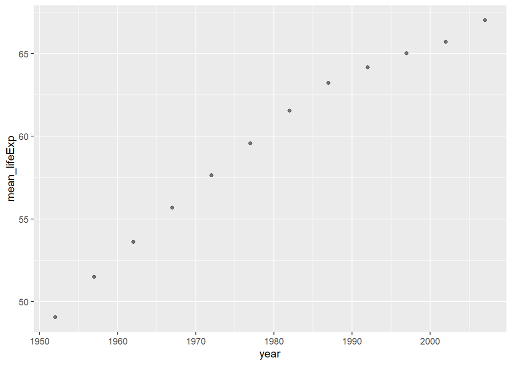

```r
scatter_plot <- function(data_frame, x_axis, y_axis ) {
  ggplot(data_frame, aes(x = {{ x_axis }}, y = {{ y_axis }})) +
    geom_point(alpha = 0.5)
}

gapminder %>%
  gap_mean_name_multicols(year, lifeExp) %>%
  scatter_plot(year, mean_lifeExp)
```

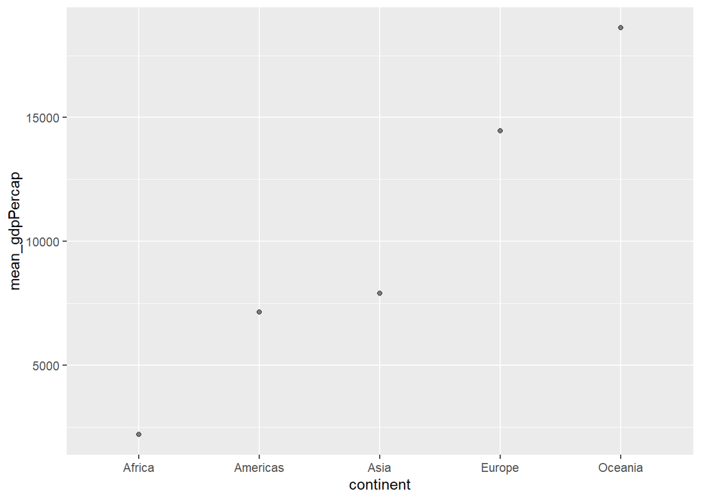

```r
gapminder %>%
  gap_mean_name_multicols(continent, gdpPercap) %>%
  scatter_plot(continent, mean_gdpPercap)
```

- or subset the data using `.data[[ ]]` and input strings to the function call

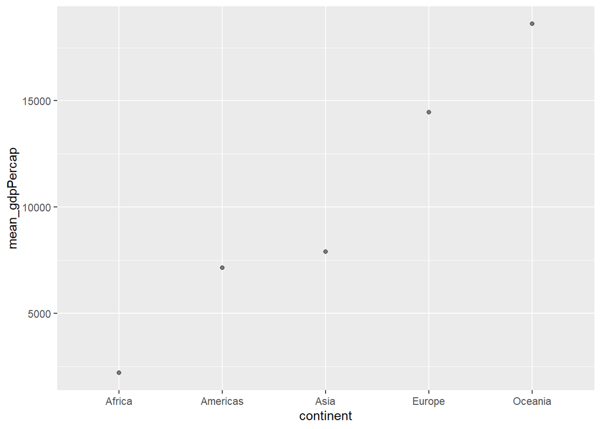

```r
scatter_plot <- function(data_frame, x_axis, y_axis ) {
  ggplot(data_frame, aes(x = .data[[x_axis]], y = .data[[y_axis]])) +
    geom_point(alpha = 0.5)
}

gapminder %>%
  gap_mean_name_multicols(continent, gdpPercap) %>%
  scatter_plot("continent", "mean_gdpPercap")
```

- or pass the dots `(…)` - can pass the dots to `aes()` or to `vars()`

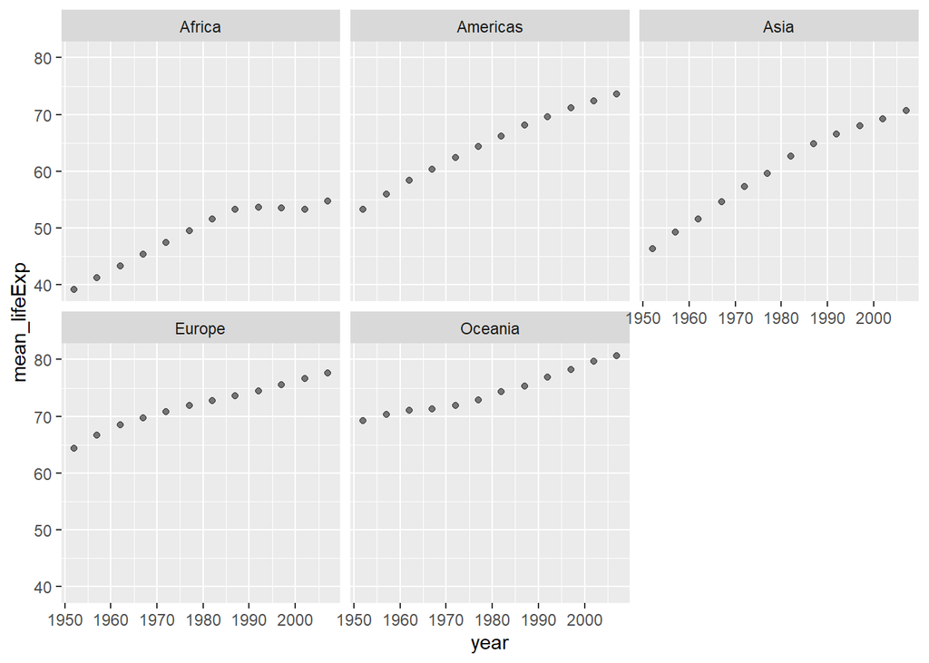

```r
scatter_facet_plot <- function(data_frame, x_axis, y_axis, ...) {
  ggplot(data_frame, aes(x = {{ x_axis }}, y = {{ y_axis }})) +
    geom_point(alpha = 0.5) +
    facet_wrap(vars(...))
}

gapminder %>%
  grouped_mean_dots(lifeExp, continent, year) %>%
  scatter_facet_plot(x_axis = year, y_axis = mean_lifeExp, continent)
```

For more ggplot examples see: `docs/ggplot_bespoke_functions_examples.docx`

## Do you even need Tidy Eval?

#### Not if you can assume fixed column names in data!

- Need to add checks on inputs (column existence, scale of values) in the function

```r
# Calculate lifeExp / pop (a contrived example)

life_v_pop <- function(data){
  if(all(c("lifeExp", "pop") %in% names(data))) {
    data %>% mutate(life_v_pop = lifeExp / pop)

  } else {
    stop("dataset must contain columns named `lifeExp` and `pop`")
  }
}

life_v_pop(gapminder)
life_v_pop(mtcars)
```

#### Not if you can select the columns you need using across() with tidy-select

- across(everything(), mean) –> map over all columns
- across(where(is.numeric), sd) –> map over columns selected by condition
- across(c(country, continent), to_upper) –> map over a custom selection

```r
#Scale all numeric variables by SD (function will work on any dataset)
my_scale <- function(data){
  data %>% mutate(across(where(is.numeric), sd, .names="sd_{.col}"))
}

my_scale(gapminder)
```

```
## # A tibble: 1,704 x 10
##    country    continent  year lifeExp    pop gdpPercap sd_year sd_lifeExp sd_pop
##    <fct>      <fct>     <int>   <dbl>  <int>     <dbl>   <dbl>      <dbl>  <dbl>
##  1 Afghanist~ Asia       1952    28.8 8.43e6      779.    17.3       12.9 1.06e8
##  2 Afghanist~ Asia       1957    30.3 9.24e6      821.    17.3       12.9 1.06e8
##  3 Afghanist~ Asia       1962    32.0 1.03e7      853.    17.3       12.9 1.06e8
##  4 Afghanist~ Asia       1967    34.0 1.15e7      836.    17.3       12.9 1.06e8
##  5 Afghanist~ Asia       1972    36.1 1.31e7      740.    17.3       12.9 1.06e8
##  6 Afghanist~ Asia       1977    38.4 1.49e7      786.    17.3       12.9 1.06e8
##  7 Afghanist~ Asia       1982    39.9 1.29e7      978.    17.3       12.9 1.06e8
##  8 Afghanist~ Asia       1987    40.8 1.39e7      852.    17.3       12.9 1.06e8
##  9 Afghanist~ Asia       1992    41.7 1.63e7      649.    17.3       12.9 1.06e8
## 10 Afghanist~ Asia       1997    41.8 2.22e7      635.    17.3       12.9 1.06e8
## # ... with 1,694 more rows, and 1 more variable: sd_gdpPercap <dbl>
```

```r
my_scale(mtcars)
```

```
##                      mpg cyl  disp  hp drat    wt  qsec vs am gear carb
## Mazda RX4           21.0   6 160.0 110 3.90 2.620 16.46  0  1    4    4
## Mazda RX4 Wag       21.0   6 160.0 110 3.90 2.875 17.02  0  1    4    4
## Datsun 710          22.8   4 108.0  93 3.85 2.320 18.61  1  1    4    1
## Hornet 4 Drive      21.4   6 258.0 110 3.08 3.215 19.44  1  0    3    1
## Hornet Sportabout   18.7   8 360.0 175 3.15 3.440 17.02  0  0    3    2
## Valiant             18.1   6 225.0 105 2.76 3.460 20.22  1  0    3    1
## Duster 360          14.3   8 360.0 245 3.21 3.570 15.84  0  0    3    4
## Merc 240D           24.4   4 146.7  62 3.69 3.190 20.00  1  0    4    2
## Merc 230            22.8   4 140.8  95 3.92 3.150 22.90  1  0    4    2
## Merc 280            19.2   6 167.6 123 3.92 3.440 18.30  1  0    4    4
## Merc 280C           17.8   6 167.6 123 3.92 3.440 18.90  1  0    4    4
## Merc 450SE          16.4   8 275.8 180 3.07 4.070 17.40  0  0    3    3
## Merc 450SL          17.3   8 275.8 180 3.07 3.730 17.60  0  0    3    3
## Merc 450SLC         15.2   8 275.8 180 3.07 3.780 18.00  0  0    3    3
## Cadillac Fleetwood  10.4   8 472.0 205 2.93 5.250 17.98  0  0    3    4
## Lincoln Continental 10.4   8 460.0 215 3.00 5.424 17.82  0  0    3    4
## Chrysler Imperial   14.7   8 440.0 230 3.23 5.345 17.42  0  0    3    4
## Fiat 128            32.4   4  78.7  66 4.08 2.200 19.47  1  1    4    1
## Honda Civic         30.4   4  75.7  52 4.93 1.615 18.52  1  1    4    2
## Toyota Corolla      33.9   4  71.1  65 4.22 1.835 19.90  1  1    4    1
## Toyota Corona       21.5   4 120.1  97 3.70 2.465 20.01  1  0    3    1
## Dodge Challenger    15.5   8 318.0 150 2.76 3.520 16.87  0  0    3    2
## AMC Javelin         15.2   8 304.0 150 3.15 3.435 17.30  0  0    3    2
## Camaro Z28          13.3   8 350.0 245 3.73 3.840 15.41  0  0    3    4
## Pontiac Firebird    19.2   8 400.0 175 3.08 3.845 17.05  0  0    3    2
## Fiat X1-9           27.3   4  79.0  66 4.08 1.935 18.90  1  1    4    1
## Porsche 914-2       26.0   4 120.3  91 4.43 2.140 16.70  0  1    5    2
## Lotus Europa        30.4   4  95.1 113 3.77 1.513 16.90  1  1    5    2
## Ford Pantera L      15.8   8 351.0 264 4.22 3.170 14.50  0  1    5    4
## Ferrari Dino        19.7   6 145.0 175 3.62 2.770 15.50  0  1    5    6
## Maserati Bora       15.0   8 301.0 335 3.54 3.570 14.60  0  1    5    8
## Volvo 142E          21.4   4 121.0 109 4.11 2.780 18.60  1  1    4    2
##                       sd_mpg   sd_cyl  sd_disp    sd_hp   sd_drat     sd_wt
## Mazda RX4           6.026948 1.785922 123.9387 68.56287 0.5346787 0.9784574
## Mazda RX4 Wag       6.026948 1.785922 123.9387 68.56287 0.5346787 0.9784574
## Datsun 710          6.026948 1.785922 123.9387 68.56287 0.5346787 0.9784574
## Hornet 4 Drive      6.026948 1.785922 123.9387 68.56287 0.5346787 0.9784574
## Hornet Sportabout   6.026948 1.785922 123.9387 68.56287 0.5346787 0.9784574
## Valiant             6.026948 1.785922 123.9387 68.56287 0.5346787 0.9784574
```

[output cut: 44 more lines]

```
## Fiat 128            1.786943 0.5040161 0.4989909 0.7378041  1.6152
## Honda Civic         1.786943 0.5040161 0.4989909 0.7378041  1.6152
## Toyota Corolla      1.786943 0.5040161 0.4989909 0.7378041  1.6152
## Toyota Corona       1.786943 0.5040161 0.4989909 0.7378041  1.6152
## Dodge Challenger    1.786943 0.5040161 0.4989909 0.7378041  1.6152
## AMC Javelin         1.786943 0.5040161 0.4989909 0.7378041  1.6152
## Camaro Z28          1.786943 0.5040161 0.4989909 0.7378041  1.6152
## Pontiac Firebird    1.786943 0.5040161 0.4989909 0.7378041  1.6152
## Fiat X1-9           1.786943 0.5040161 0.4989909 0.7378041  1.6152
## Porsche 914-2       1.786943 0.5040161 0.4989909 0.7378041  1.6152
## Lotus Europa        1.786943 0.5040161 0.4989909 0.7378041  1.6152
## Ford Pantera L      1.786943 0.5040161 0.4989909 0.7378041  1.6152
## Ferrari Dino        1.786943 0.5040161 0.4989909 0.7378041  1.6152
## Maserati Bora       1.786943 0.5040161 0.4989909 0.7378041  1.6152
## Volvo 142E          1.786943 0.5040161 0.4989909 0.7378041  1.6152
```

```r
#Another example -> mean of all numeric cols, grouped by all factor variables
my_gp_summarise <- function(data){
  data %>%
    group_by(across(where(is.factor))) %>%
    summarise(across(where(is.numeric), mean, .names="mean_{.col}"))
}

# works on any dataset
my_gp_summarise(gapminder)
```

```
## # A tibble: 142 x 6
## # Groups:   country [142]
##    country     continent mean_year mean_lifeExp  mean_pop mean_gdpPercap
##    <fct>       <fct>         <dbl>        <dbl>     <dbl>          <dbl>
##  1 Afghanistan Asia          1980.         37.5 15823715.           803.
##  2 Albania     Europe        1980.         68.4  2580249.          3255.
##  3 Algeria     Africa        1980.         59.0 19875406.          4426.
##  4 Angola      Africa        1980.         37.9  7309390.          3607.
##  5 Argentina   Americas      1980.         69.1 28602240.          8956.
##  6 Australia   Oceania       1980.         74.7 14649312.         19981.
##  7 Austria     Europe        1980.         73.1  7583298.         20412.
##  8 Bahrain     Asia          1980.         65.6   373913.         18078.
##  9 Bangladesh  Asia          1980.         49.8 90755395.           818.
## 10 Belgium     Europe        1980.         73.6  9725119.         19901.
## # ... with 132 more rows
```

```r
my_gp_summarise(mtcars)
```

```
## # A tibble: 1 x 11
##   mean_mpg mean_cyl mean_disp mean_hp mean_drat mean_wt mean_qsec mean_vs
##      <dbl>    <dbl>     <dbl>   <dbl>     <dbl>   <dbl>     <dbl>   <dbl>
## 1     20.1     6.19      231.    147.      3.60    3.22      17.8   0.438
## # ... with 3 more variables: mean_am <dbl>, mean_gear <dbl>, mean_carb <dbl>
```

## Do we ever need for loops?

```r
columns <- names(gapminder)[4:6]
out <- rep(list(NULL), 3)

for(col in seq_along(columns)){
  out[[col]] <- gapminder %>%
    summarise(mean = mean(columns[[col]], na.rm = T))
}

unlist(out)
```

It doesn’t work because `columns[[col]]`, a string representing the name of a column in gapminder, is not recognised as a data variable within the context of the `mean` function. Now we can try again using the `.data` pronoun.

```r
columns <- names(gapminder)[4:6]
out <- rep(list(NULL), 3)

for(col in columns){
  out[[col]] <- gapminder %>%
    summarise(mean = mean(.data[[col]]))
}

unlist(out)
```

```
##   lifeExp.mean       pop.mean gdpPercap.mean
##   5.947444e+01   2.960121e+07   7.215327e+03
```

It worked but it’s ugly and we have an awkward output format. We can improve this by using the tidy selection function `across` to drop the for loop:

```r
columns <- names(gapminder)[4:6]
gapminder %>%
  summarise(across(all_of(columns), mean, .names="{.col}.mean"))
```

```
## # A tibble: 1 x 3
##   lifeExp.mean  pop.mean gdpPercap.mean
##          <dbl>     <dbl>          <dbl>
## 1         59.5 29601212.          7215.
```

```r
# or, if we have parameters, use a dot to represent the current data variable
gapminder %>%
    summarise(across(all_of(columns), ~ mean(., na.rm = T), .names="{.col}.mean"))
```

```
## # A tibble: 1 x 3
##   lifeExp.mean  pop.mean gdpPercap.mean
##          <dbl>     <dbl>          <dbl>
## 1         59.5 29601212.          7215.
```

> This actually means that for loops are rarely needed!